# メトロポリス・ヘイスティングス法

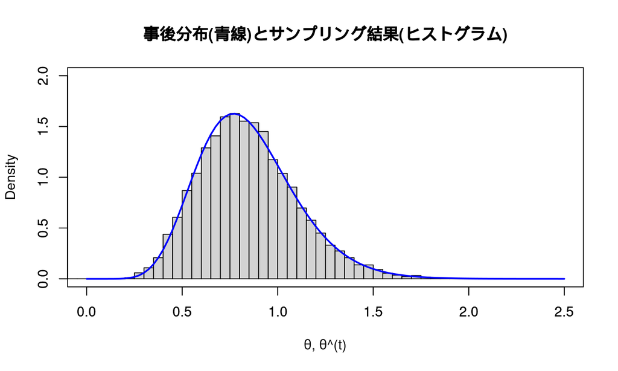

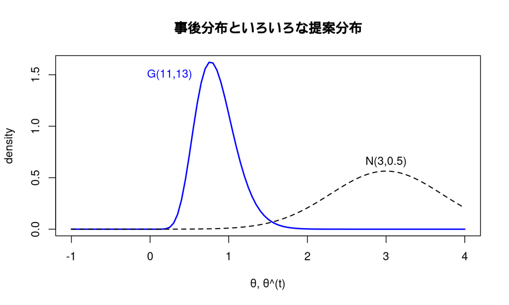

```
## 解析解
## Mean[1] 0.846
## Var[1] 0.065
## SD[1] 0.255
```

```
## [1] "proposal: N(3, 0.5)"
```

```
## 採択率[1] 0.00407
```

```
## モンテカルロ積分
## Mean[1] 0.847
## Var[1] 0.053
## SD[1] 0.229
```

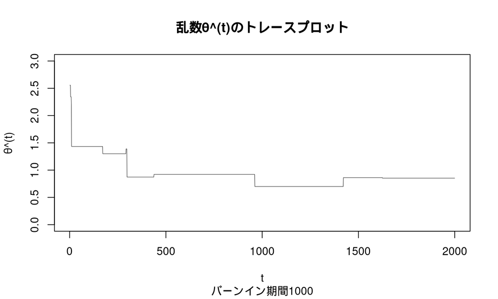

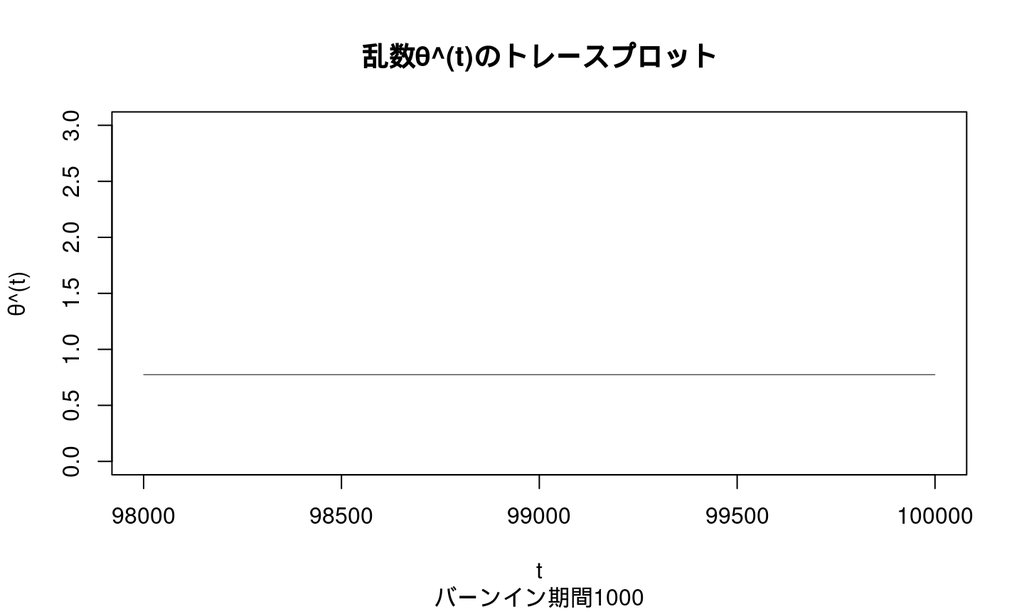

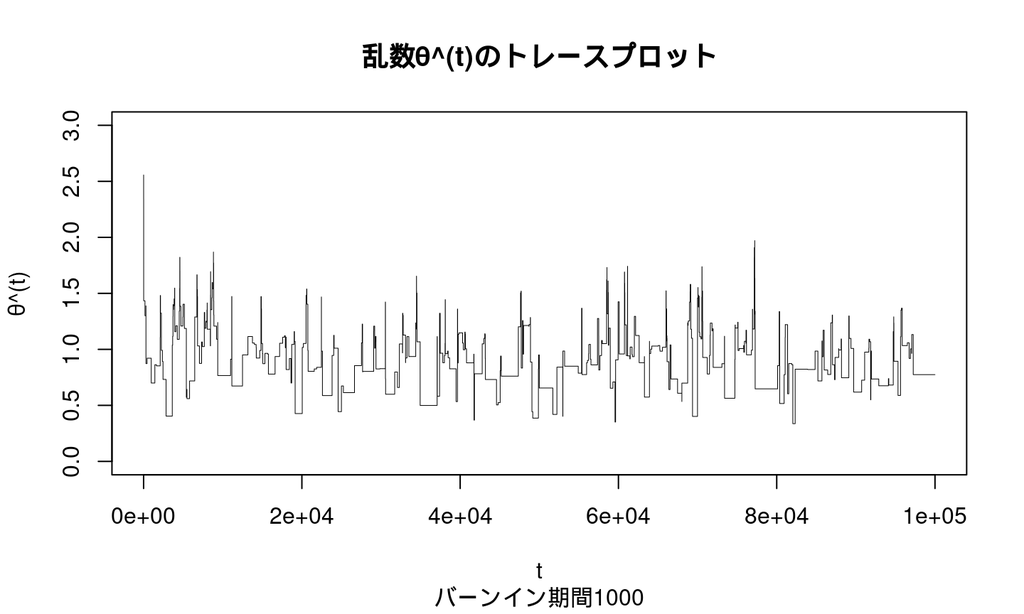

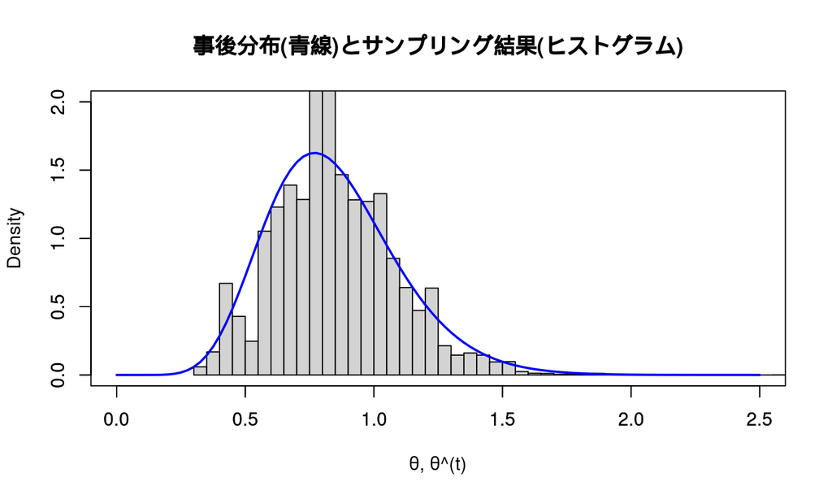

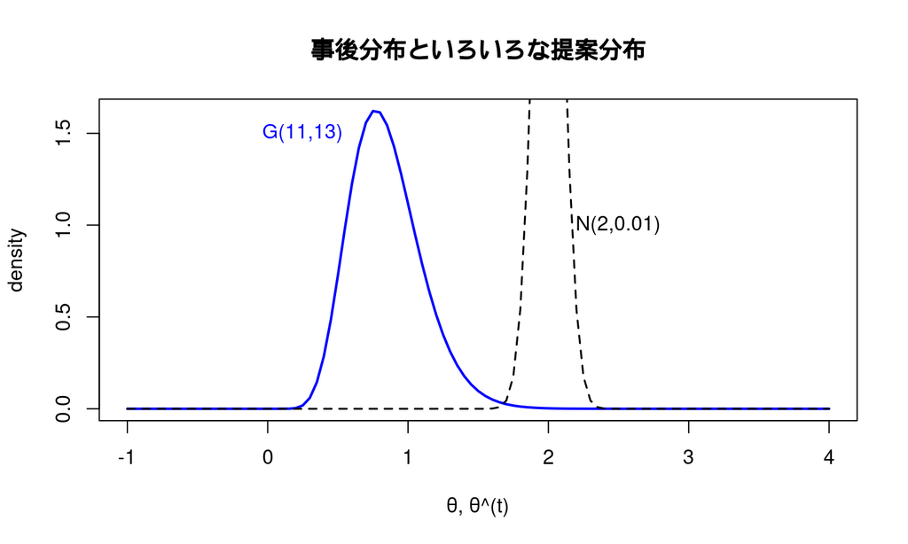

```
## 解析解
## Mean[1] 0.846
## Var[1] 0.065
## SD[1] 0.255
```

```
## [1] "proposal: N(2, 0.01)"
```

```
## 採択率[1] 0.05196
```

```
## モンテカルロ積分
## Mean[1] 1.632
## Var[1] 0.015
## SD[1] 0.123
```

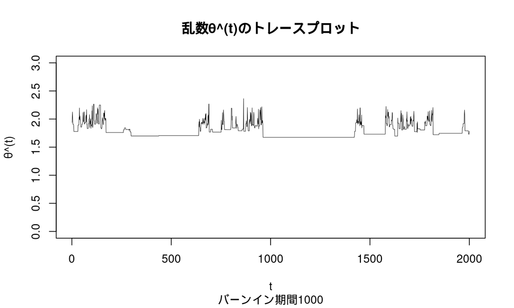

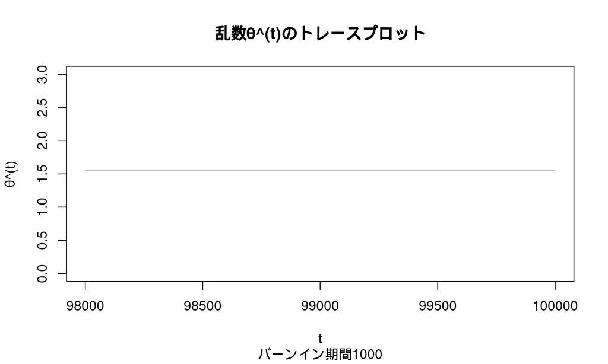

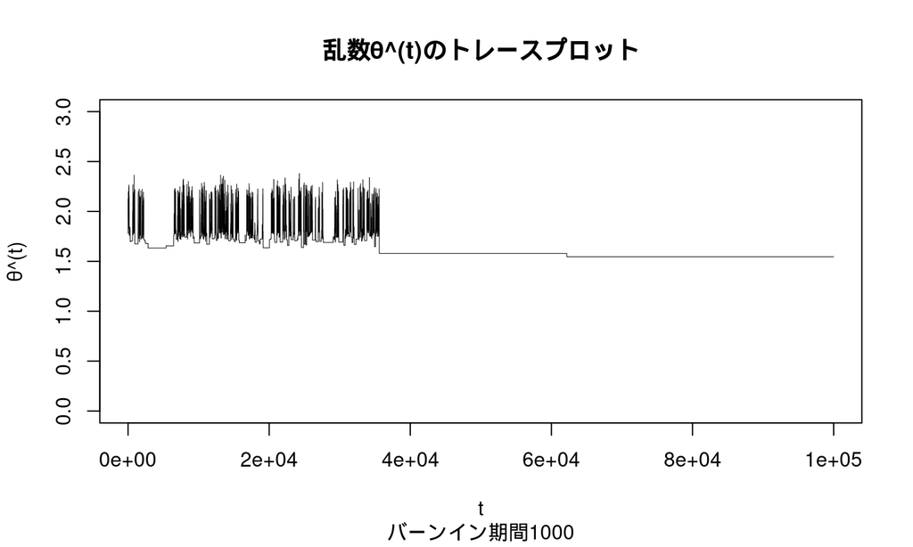

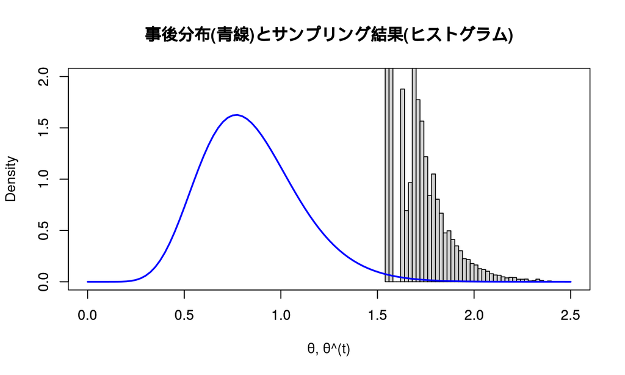

例えば提案分布が\({\rm Normal}(1, 2)\)だと, \(\theta\)の範囲はうまくカバーできてるものの事後分布と重なっている面積が小さいため受容率が低く収束も遅くなります. \({\rm Normal}(3, 0.5)\)や\({\rm Normal}(2, 0.01)\)はそもそも重なっている面積がほぼないので絶望的です.

仮に事後分布の位置や形がわかっていれば上手な提案分布を設定できるかもしれませんが, 実際の分析では事後分布の形を把握することが難しいので, 分析者がIMHの提案分布を設定するのは非常に困難です. そこでランダムウォークMHを導入します.

## ランダムウォーク メトロポリス・ヘイスティングス法 (Random Walk Metropolis-Hastings: RWMH)

RWMHはパラメータの乱数候補\(a^{(t)}\)を各ステップで提案分布\(q(|)\)から逐一drawするのではなく,

\[ a^{(t+1)} = \theta^{(t)} + e \\ e \sim {\rm Normal}(0, \delta_e^2) \ {\rm or} \ {\rm Uniform}(-\delta_e', \delta_e') \]

とします. \(e\)はノイズで, \(E[e]=0\)となるような左右対称な分布(平均0の正規分布や左右対称な一様分布)に従います. すると\(a^{(t+1)}\)は1ステップ前の乱数\(\theta^{(t)}\)と平均0のノイズ\(e\)だけで決まるランダムウォークになります.  
ランダムウォークに動くということは, 仮に1ステップ前の乱数\(\theta^{(t)}\)が“良い”乱数であれば, 次の乱数候補\(a^{(t+1)}\)もそう悪くない乱数になるということです(期待値は1ステップ前の乱数\(E[a^{(t+1)}]=\theta^{(t)}\)). これは当てずっぽうに毎ステップ同じ提案分布\(q(\cdot)\)から乱数候補をdrawするIMHよりも良さそうです.

## RWMH法

RWMHの提案分布自体は正規分布や一様分布でなくても何でもいいですが, 対称な分布にすると便利です. 対称な提案分布にすると,

\[ q(a^{(t+1)}|\theta^{(t)}) = q(\theta^{(t)}|a^{(t+1)}) \]

となります. よってRWMHの補正確率は

\[\begin{eqnarray} A(a^{(t+1)}, \theta^{(t)}) &=& \min \left(1, \frac {f(a^{(t+1)}|D)} {f(\theta^{(t)}|D)} \right) \\ \end{eqnarray}\]

となり, 補正確率\(r\)から提案分布\(q(|)\)が消えて事後分布の比だけになります. あとはいつものMH法のようにサンプリングします.

<例題>

先のIMHの例題をRWMHでやってみます. 初期値は\(\theta^{(0)}=4\)としてわざと遠くにしてみます.  
ノイズ\(e\)の分散は\(\delta_e^2=0.1\)とします(実際これは分析者が調節します).

```
## 解析解
## Mean[1] 0.846
## Var[1] 0.065
## SD[1] 0.255
```

```
## 採択率[1] 0.6381918
```

```
## モンテカルロ積分
## Mean[1] 0.849
## Var[1] 0.065
## SD[1] 0.255
```

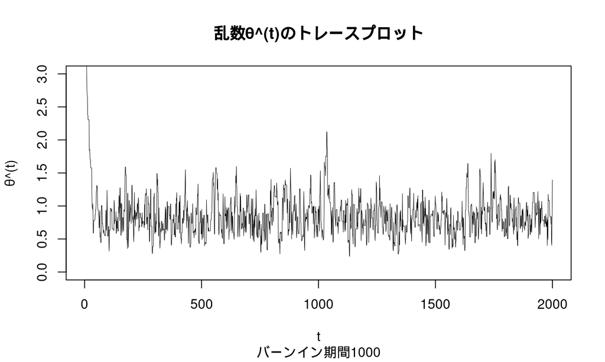

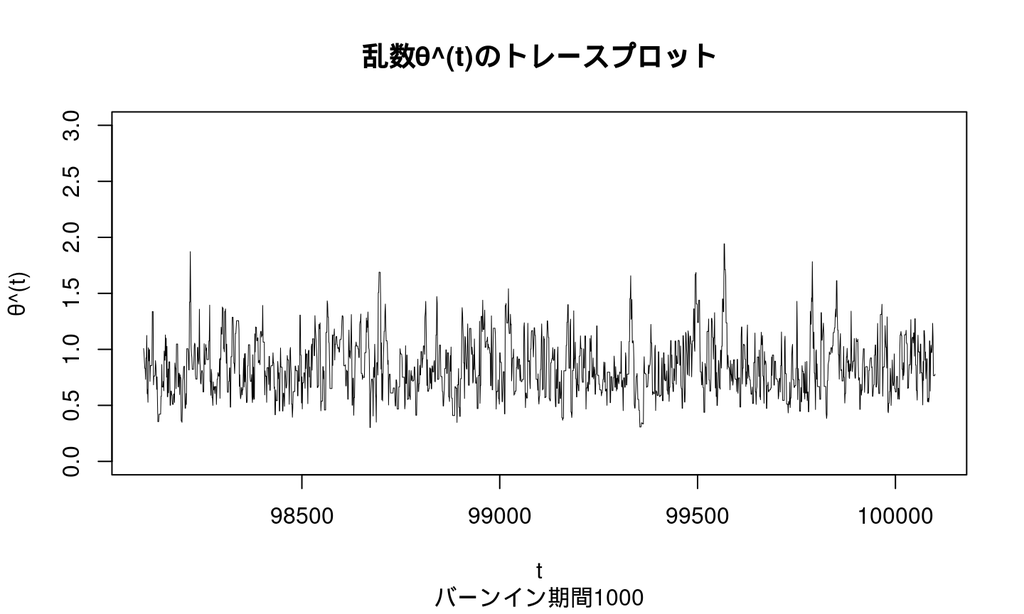

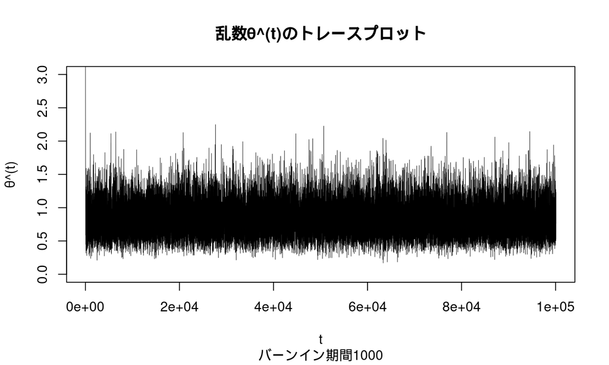

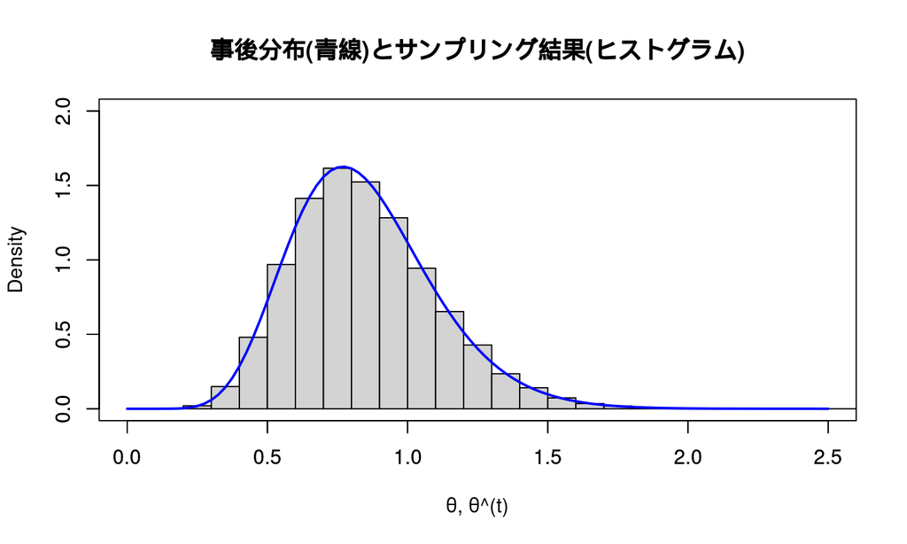

初期値がでたらめでも, IMHよりきれいに事後分布に重なったサンプリングができています(\(\delta_e\)をうまく設定できればの話ですが).

## RWMH法の弱点

RWMHの成功のカギは\(\delta_e\)をうまく設定できるかどうかです. \(\delta_e\)が大きすぎると, 1回ランダムウォークの移動距離が長く, 目標分布の確率密度が高い領域になかなか入れずに受容率が下がってしまいます.  
反対に\(\delta_e\)が小さすぎると, 1回ランダムウォークの移動距離が短く, 収束まで時間がかかってしまいます(乱数同士が相関). \(\delta_e\)はハイパーパラメータなので分析者が地道にちょうどいい値を探すしかありません.

\(\delta_e = 100000\): 1ステップの移動幅が超デカい

```
## 解析解
## Mean[1] 0.846
## Var[1] 0.065
## SD[1] 0.255
```

```
## 採択率[1] 0.001008991
```

```
## モンテカルロ積分
## Mean[1] 0.852
## Var[1] 0.079
## SD[1] 0.281
```

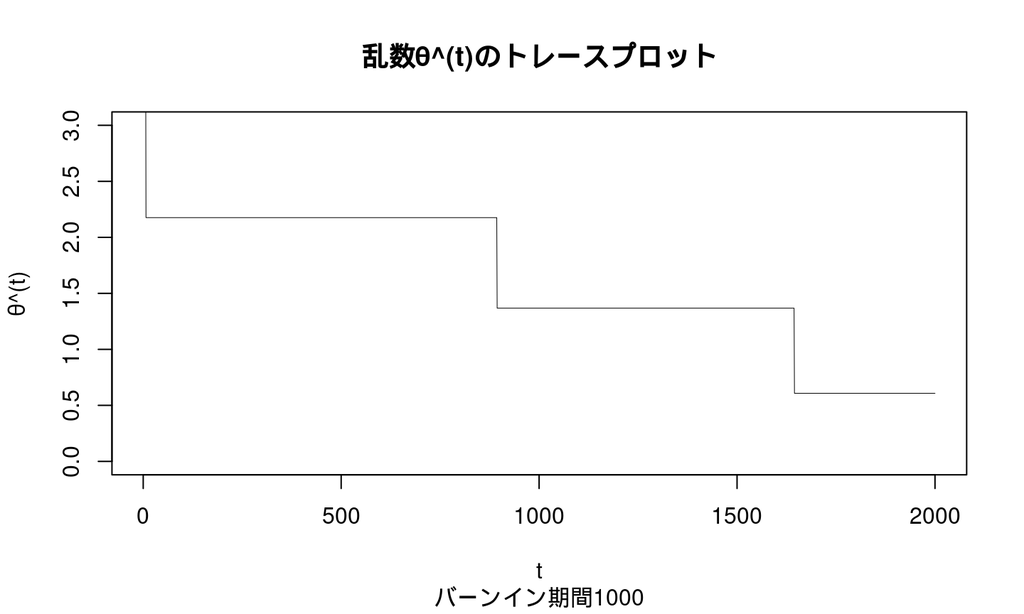

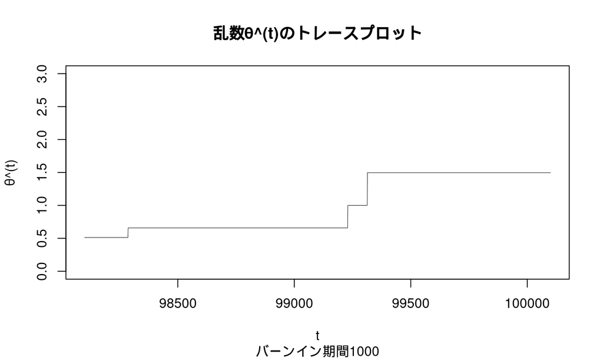

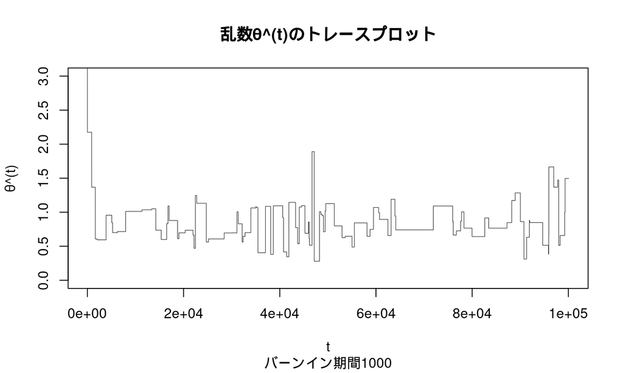

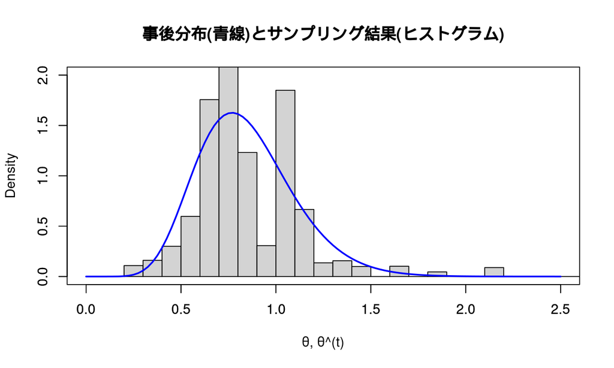

\(\delta_e = 0.00001\): 1ステップの移動幅が超小さい

```
## 解析解
## Mean[1] 0.846
## Var[1] 0.065
## SD[1] 0.255
```

```
## 採択率[1] 0.9922877
```

```
## モンテカルロ積分
## Mean[1] 1.805
## Var[1] 0.771
## SD[1] 0.878
```

[figure not shown]

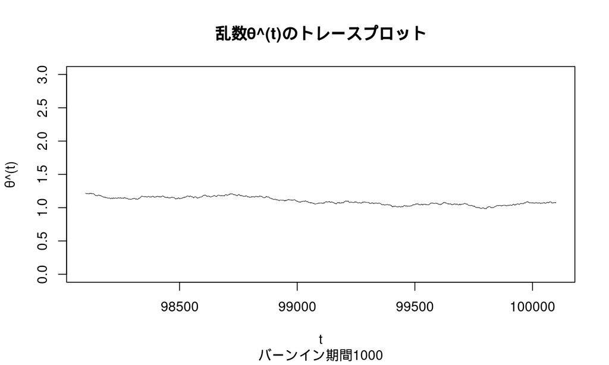

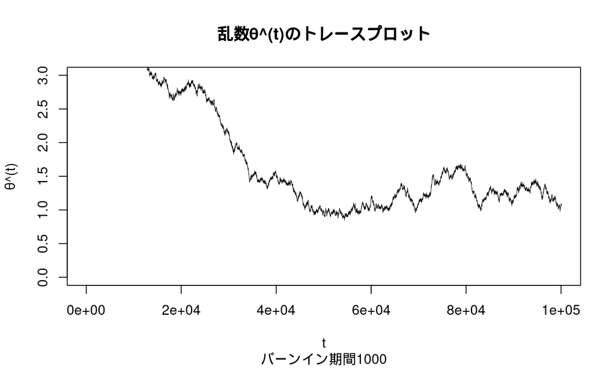

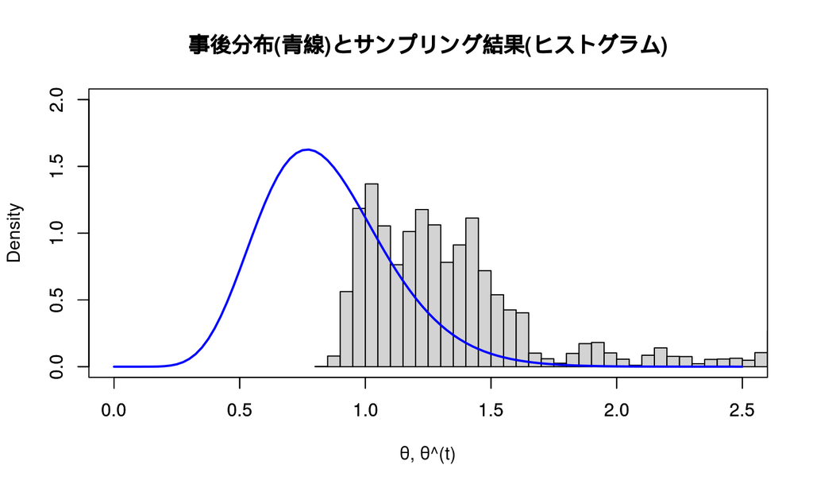

先の例題ではポアソン分布のパラメータ1つだけの推定でしたが,  
回帰モデルを推定する際, 回帰モデルには複数推定するパラメータがあります.  
なのでRWMHはその分だけノイズの分散\(\delta_{e1}, \delta_{e2}, ..., \delta_{ek}\)を設定し, 別々に乱数をサンプリングしなければなりません.  
こうなるとハイパーパラメータの設定はさらに難しくなります.

回帰モデル

\[\begin{eqnarray} y_i &=& \beta_0 + \beta_1 X_{1i}+ \beta_2 X_{2i} + \cdots + \beta_k X_{ki} + \epsilon_i, \ \epsilon_i \sim N(0, \sigma^2) \\ \iff y_i|_{{\bf X_i}, \ \beta_0, \ \beta_1, \ \cdots, \ \beta_k, \ \sigma} &\sim& N(\beta_0 + \beta_1 X_{1i}+ \beta_2 X_{2i} + \cdots + \beta_k X_{ki}, \sigma^2) \\ \end{eqnarray}\]

乱数候補のランダムウォーク

\[\begin{eqnarray} \left( \begin{array}{c} a_{\beta_0}^{(t)} \\ a_{\beta_1}^{(t)} \\ \vdots \\ a_{\beta_k}^{(t)} \\ a_{\sigma}^{(t)} \\ \end{array} \right) &=& \left( \begin{array}{c} \beta_0^{(t-1)} \\ \beta_1^{(t-1)} \\ \vdots \\ \beta_k^{(t-1)} \\ \sigma^{(t-1)} \\ \end{array} \right) + \left( \begin{array}{c} e_{\beta_0} \\ e_{\beta_1} \\ \vdots \\ e_{\beta_k} \\ e_{\sigma} \\ \end{array} \right) \\ \left( \begin{array}{c} e_{\beta_0} \\ e_{\beta_1} \\ \vdots \\ e_{\beta_k} \\ e_{\sigma} \\ \end{array} \right) &\sim& N \left( \begin{array}{c} 0, \delta_{e\beta_0}^2 \\ 0, \delta_{e\beta_1}^2 \\ \vdots \\ 0, \delta_{e\beta_k}^2 \\ 0, \delta_{e\sigma}^2 \\ \end{array} \right) \\ \end{eqnarray}\]

\[\begin{eqnarray} \left( \begin{array}{c} e_{\beta_0} \\ e_{\beta_1} \\ \vdots \\ e_{\beta_k} \\ e_{\sigma} \\ \end{array} \right) &\sim& N \left( \left( \begin{array}{c} 0 \\ 0 \\ \vdots \\ 0 \\ 0 \\ \end{array} \right), \left( \begin{array}{ccccc} \delta_{e\beta_0}^2 & 0 & \cdots & 0 & 0 \\ 0 & \delta_{e\beta_1}^2 & \cdots & 0 & 0 \\ \vdots & \vdots & \ddots & \vdots & \vdots \\ 0 & 0 & \cdots & \delta_{e\beta_k}^2 & 0 \\ 0 & 0 & \cdots & 0 & \delta_{e\sigma}^2 \\ \end{array} \right) \right) \end{eqnarray}\]

## RWMH法: 複数パラメータの場合

<例題>

以下のデータを回帰する.

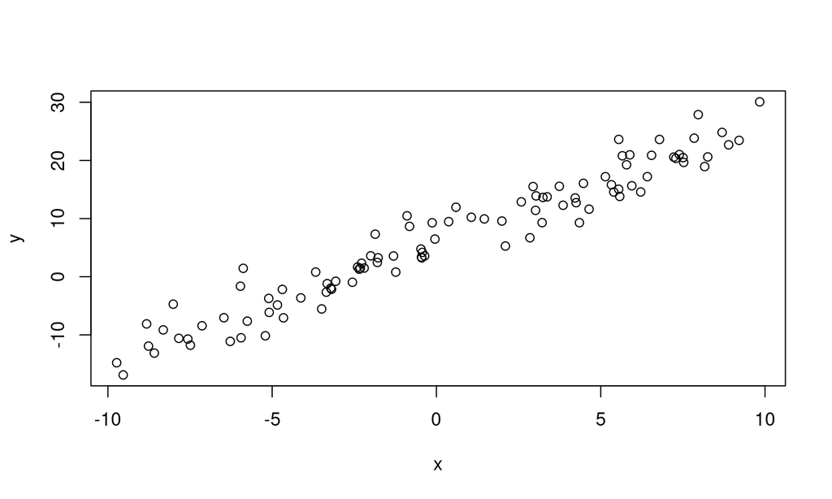

推定するモデルは以下の通り.

\[\begin{eqnarray} y_i &=& \beta_0 + \beta_1 X_{i} + \epsilon_i, \ \epsilon_i \sim N(0, \sigma^2) \\ \iff y_i|_{X_i, \ \beta_0, \ \beta_1, \ \sigma} &\sim& N(\beta_0 + \beta_1 X_{i}, \ \sigma^2) \\ \\ \end{eqnarray}\]

発生させる乱数は以下の通り

\[\begin{eqnarray} \left( \begin{array}{c} a_{\beta_0}^{(t)} \\ a_{\beta_1}^{(t)} \\ a_{\sigma}^{(t)} \\ \end{array} \right) &=& \left( \begin{array}{c} \beta_0^{(t-1)} \\ \beta_1^{(t-1)} \\ \sigma^{(t-1)} \\ \end{array} \right) + \left( \begin{array}{c} e_{\beta_0} \\ e_{\beta_1} \\ e_{\sigma} \\ \end{array} \right) \\ \left( \begin{array}{c} e_{\beta_0} \\ e_{\beta_1} \\ e_{\sigma} \\ \end{array} \right) &\sim& N \left( \left( \begin{array}{c} 0 \\ 0 \\ 0 \\ \end{array} \right), \left( \begin{array}{ccc} \delta_{e\beta_0}^2 & 0 & 0 \\ 0 & \delta_{e\beta_1}^2 & 0 \\ 0 & 0 & \delta_{e\sigma}^2 \\ \end{array} \right) \right) \\ e_\sigma &\geq& 0\\ \end{eqnarray}\]